# SAGE-I: Genome Annotation

German Bonilla-Rosso[^1]

2022-11-22

# Before we start…

You’ve got some genome assemblies now! Now the fun part begins…

In this tutorial, we are going to run *genome assembly quality checks* with **CheckM**, and accurately *infer the taxonomy* of our genomes by placing them into a genome-wide bacterial phylogeny with the **GTDBtk**, and finally *predict the genes and their functional potential* with **DRAM**.

This tutorial will be a bit different from the previous ones, in that I’ve prepared scripts to install and run the software we need. So the idea is that you finish running these scripts as fast as possible, integrating them at the end so we get enough time to have fun with the results!

# 1 : Prepare all scripts and data

- Log into `curnagl` (duh!)

### 1.1. Start conda

```bash
#  Load the modules needed into the cluster to run conda
$ module load gcc miniconda3
$ conda init bash #  ONLY FOR THE VERY FIRST time you use it
```

This will ask you for a password. IGNORE IT and cancel it with `<Ctrl+C>`.

- log-off `curnagl`… and log-in again! (yes, like magick)

### 1.2 Set up the directories (don’t forget to change your username and genomeID here!)

```bash
#  Don't forget to change <username> and <genomeID> to your own!
user=username
id=genomeID
mkdir /scratch/jgianott/SAGE/SAGE2022_2023/common_files/checkM/${user}/conda_pkg
mkdir /scratch/jgianott/SAGE/SAGE2022_2023/common_files/checkM/${user}/mycondaenvs
mkdir /scratch/jgianott/SAGE/SAGE2022_2023/${user}/04_checkm
cd /scratch/jgianott/SAGE/SAGE2022_2023/${user}/04_checkm
```

- Copy the scripts into your directory AND insert your `username` adn your `genomeID` in each script

```bash
cd /scratch/jgianott/SAGE/SAGE2022_2023/common_files/04_CheckM/
for i in *sh; do
  sed "s/username/${user}/g" $i | sed "s/genomeID/${id}/g" > /scratch/jgianott/SAGE/SAGE2022_2023/${user}/${i}
done

# make sure your FINAL polished assembly is in this path (and has that name):
/scratch/jgianott/SAGE/SAGE2022_2023/${user}/02_assembly_ONT/Polishing_Illumina/05_third_pillon_bowtie2/assembly/${id}_third_Pilon_Assembly.fasta
```

# 2 : Run the install script (8min)

```bash
#  Remember you should be in your own /scratch directory!
cd /scratch/jgianott/SAGE/SAGE2022_2023/${user}
sbatch ./00_install.sh
```

- When finished, make sure you have the following:

```bash
/scratch/jgianott/SAGE/SAGE2022_2023/common_files/checkM/${user}/checkmDB
/scratch/jgianott/SAGE/SAGE2022_2023/${user}/04_checkm/checkm_test_results
```

# 3: Run CheckM (6min)

For quality control we will use **CheckM**, an awesome piece of software widely used to check the quality of genome assemblies. It was made thinking of checking genomes obtained from metagenomes (*bins* or *binned genomes*).

```bash
#  Easy peasy
cd /scratch/jgianott/SAGE/SAGE2022_2023/${user}
sbatch ./01_checkm.sh
```

- When finished:
  - Check for errors in your `.err` and `.out` files
  - Check you have the following:

```bash
/scratch/jgianott/SAGE/SAGE2022_2023/${user}/04_checkm/assemblies/${id}.fna
/scratch/jgianott/SAGE/SAGE2022_2023/${user}/04_checkm/results/CheckM_QC_f2.tsv
```

- Now ain’t the time to be curious. Go directly into the next section, we’ll explore the results later. The next step takes long!

# Part 3: Run GTDBtk (10min)

A unique initiative to establish standardised microbial taxonomy based on whole genome phylogenies is the *Genome Taxonomy Database* (**GTDB**). It uses a similar approach as *CheckM*: it contains a reference database of 120 single-copy marker proteins from ~65’700 species (317’542 genomes), and a carefully constructed phylogeny. The GTDB taxonomic ranks are standardised by phylogenetic distance. Each time you classify a genome, it searches the 120 marker genes in your genome, aligns it to the reference and places it in the standardised phylogeny. To resolve closely-related genomes at species level and below, it uses an *Average Nucleotide Identity* (ANI) index.

```bash
#  Easy peasy
sbatch ./02_gtdbtk.sh
```

- When finished, make sure you have the following files:

```bash
/scratch/jgianott/SAGE/SAGE2022_2023/${user}/04_checkm/gtdb/${id}_gtdbtk.bac120.summary.tsv
```

# 4: Run DRAM (20min)

Our annotation software will be **DRAM**, another impressive software that calls genes in your genome, and then annotate the translated proteins using a large array of reference databases (PFAM, KEGG, UniProt, CAZY, MEROPS, and more!). It prides itself on being a data aggreggator, so it can take custom made databases and data from other sources. In this case, we will also feed it with the analysis made by **CheckM**. One nice thing about **DRAM** is that it aggregates all data to generate nice overviews of your results that they call the *distillate*.

- Run the annotation (DRAM) script

```bash
sbatch ./03_dram
```

- When finished, make sure you have the following files:

```bash
/scratch/jgianott/SAGE/SAGE2022_2023/${user}/05_dram/annoDRAM_${id}/annotations.tsv
/scratch/jgianott/SAGE/SAGE2022_2023/${user}/05_dram/annoDRAM_${id}/distill/
```

# 5: Download the output files to your local computer

The final, aggregated output of DRAM is quite cumbersome to read on the terminal, so you’re gonna download them into your own machine for easier exploration.

```bash
# From your own local terminal (NOT the cluster):
scp ${user}@curnagl.dcsr.unil.ch:/scratch/jgianott/SAGE/SAGE2022_2023/${user}/05_dram/annoDRAM_${id}/distill/"*" ./
```

- Once finished, you should have the following files and you should be able to expore them with the following program:

```bash
genome_stats.tsv          ->  MSExcel
metabolism_summary.xlsx   ->  MSExcel
product.tsv               ->  MSExcel
product.html              ->  WebBrowser
```

# 6: Analyse the Results!

## GTDBtk Taxonomy

You can check the full taxonomy that GTDBtk resolved for your genome in the 2nd column of the `/05_dram/annoDRAM_ESL0976/distill/genome_stats.tsv` file. For a deeper inspection of how it came to this result, you can inspect the `04_checkm/gtdb/${id}_gtdbtk.bac120.summary.tsv` file. Have a look at that file and decide how trustworthy is this taxonomic assignment. Then fill that part in the google spreadsheet.

## CheckM quality

Inspect the **CheckM** results for your own genome and identify its strong points and its weak points. These are summarised in the `genome_stats.tsv` file, but you can also explore the `checkm` output (See the APPENDIX below).

### Genes predicted

A good way to give you a quick look at how well the genome is annotated is counting the number of genes/proteins predicted in your genome. They should roughly correspond to 1 gene/protein per 1’000 bp. Can you think of a quick one-liner to count genes? grep -c ‘>’ /scratch/jgianott/SAGE/SAGE2022_2023/${user}/05_dram/annoDRAM_${id}/genes.faa

### RNAs

All known genomes should have a set of rRNA and some tRNAs. The location of the predicted RNAs in your genome are in files `rrnas.tsv` and `trnas.tsv`.

- Make sure you have *at least one* copy of the entire *rrna* operon (5S, 16S, 23S). Are there any discrepancies in copy number?
- In order to function properly, a cell should in principle have *at least one* tRNA for each aminoacid. The translation are in the 6th column of the `trnas.tsv` file. Does your genome has at least one copy for each aminoacid? Does it has different tRNAs for the same aminoacid? awk -F’ ‘{print $6}’ trnas.tsv | sort | uniq -c | wc -l

### GC% Distribution

Remember we can identify some radically different contaminations (or viruses, or plasmids) inspecting the GC% skew. CheckM plots this distribution in your `04_checkm/results/plots/gc_plots.png` directory. This plot shows the GC% distribution across your genome in fragments of 5,000 bp. How can you use this to evaluate the quality? How would it look like if it contained the mixed genomes of two different bacteria?

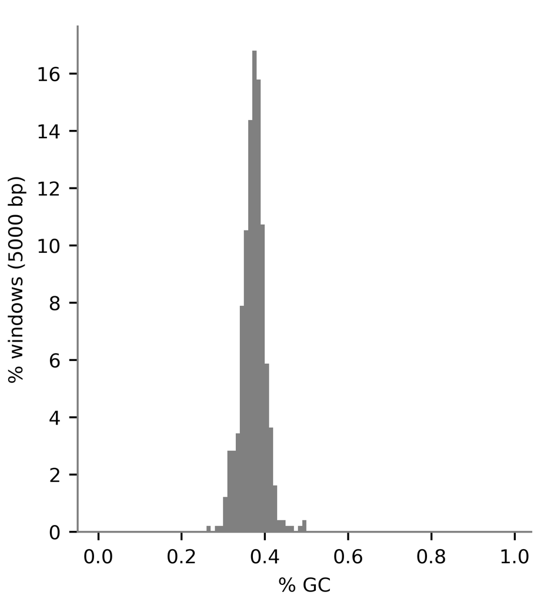

### Coding Density

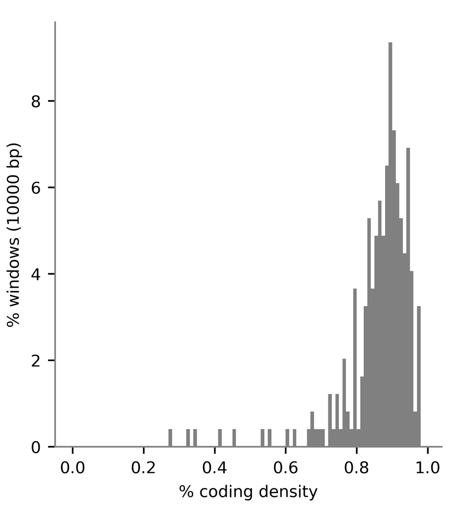

### NX values

Remember N50? Well, the plot in `04_checkm/results/plots/nx_plots.png` represents a generalization on the N50 (50%) across all percentages wished (N25, N75…), hence *Nx*. It tells you the length of the shortest contig of the largest contigs (ordered from largest to shortest), when their summed lenght is *x*, that is 25%, 50%, 75%, etc. Is this plot showing a good assembly? why?

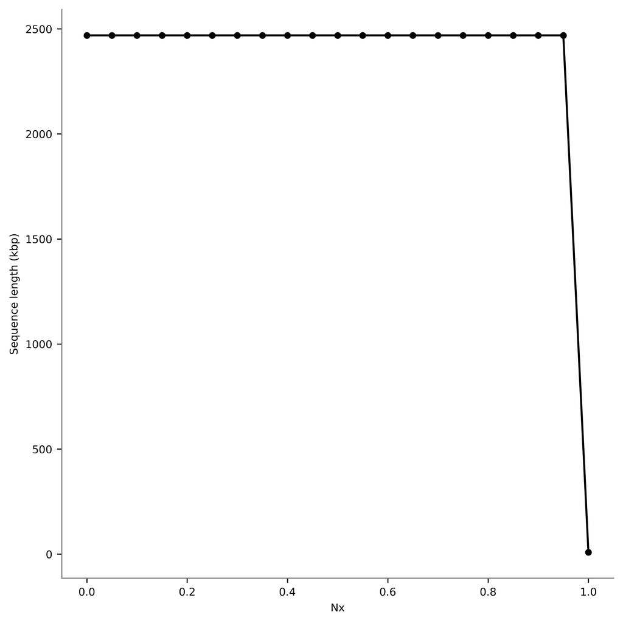

## Marker-gene set Analyses

### Distribution of the marker-sets

CheckM uses several different genes to estimate completeness. However, many times these conserved genes are in a single operon or in the same chromosomal region (e.g. all ribosomal proteins are usually in the same stretch). This means that losing a relatively short region of DNA could skew the evaluation quite drastically. So the first thing to do is to check how well distributed these genes are across our genome. - The plot in `04_checkm/results/plots/markers_pos_plots.png` shows exactly this. Each square is 1 marker set, and the colours indicate how many marker genes it contains. Are they well distributed across your genome or clustered? Why is this important for us? Marker sets are a proxy of what exactly?

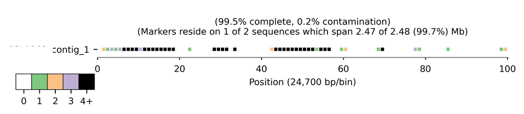

### Marker-gene sets results

You can find the marker gene results on **Completeness, Contamination* and *Strain Heterogeneity* either in the `CheckM_QC_f2.tsv` file or integrated in the `genome_stats.tsv` file. Inspect these files and decide if those levels of completeness, contamination and strain heterogeneity are sufficient to consider this a good genome assembly. You can read about all CheckM outputs in *APPENDIX*

## Veredict

How do we decide what is a good assembly and what is a bad one? There is no clear cut answer, but there are some common sense guidelines as to what is the minimum needed to report in a newly sequenced genome, and on how its quality shoudl be reported. These are gathered in the Minimum Information about a Genome Sequence specification [(MIGS)](https://www.nature.com/articles/nbt1360), and its updated form the Minimum Information about a Metagenome-Assembled Genome [(MIMAG)](https://www.nature.com/articles/nbt.3893). Here is a short summary so you get an idea:

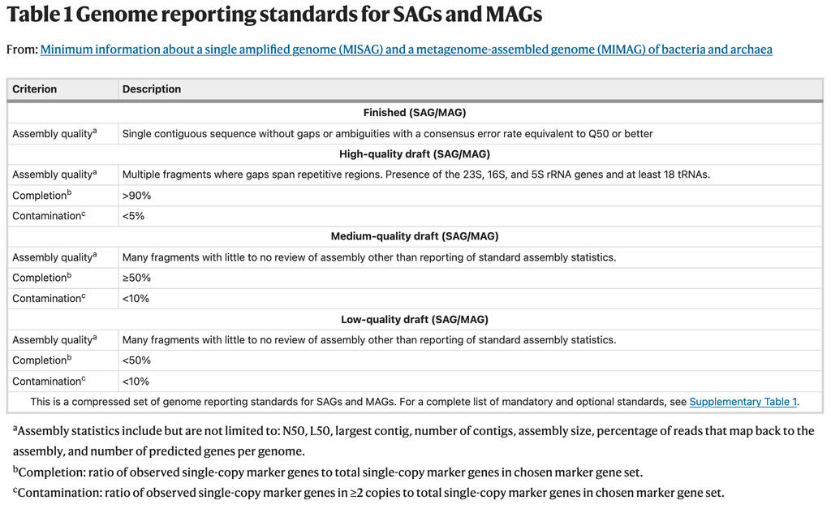

- The output of CheckM is quite extensive and extremely useful to have a full picture of the quality of your genome. You can explore a guide on how to interpret it in the **APPENDIX**.

When you’ve made a decision, write it in the last column of the group’s spreadsheet (Veredict)(https://docs.google.com/spreadsheets/d/13yoqbjZEOriaUmpEqeuugD-Fp5cr18mVFPInbiTH-sI/edit#gid=1199947108), as `Finished/High/Medium/Low quality`. `Be prepared to defend your decision!!!`

# APPENDIX - Dissecting **CheckM** processing and outputs:

## CheckM - What is it actually doing?

When invoked, **CheckM** will do the following:

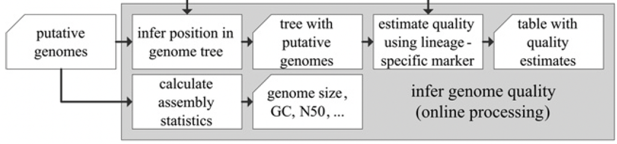

CheckM flow diagram

- Calculate the assembly statistics we reviewed last time (size, GC%, N50, etc) on your whole assembly
- **Call** (find, deduce, identify) the genes in your genome and translate them
- Compare these sequences against an internal database of **reference** genomes containing all Bacteria and Archaea
- **Map** the genes from your genome into a tree with all genomes, thus inferring the position of your genome in a reference phylogeny
- According to its position in the phylogeny, choose a set of **marker genes** that are *single-copy* (not duplicated) and *conserved* (always present) in all members of that clade.
- Search for this set of marker genes in your genome, and **estimate quality**.
- For more information you can read the paper by [Parks et al. 2015](https://genome.cshlp.org/content/25/7/1043) that describes it, and peruse the [CheckM wiki](https://github.com/Ecogenomics/CheckM/wiki).

## CheckM Output

- Open the file `CheckM_QC_f2.tsv` in MSExcel (or your favourite Spreadsheet software). Note that this is formatted with *t*ab-*s*eparated-*v*alues, you’ll need to tell this to the Spreadsheet. Two things to try:
  - Open it directly in MSExcel and let it ask you about the format. You then choose *Character delimited* (or whatever is the opposite to *Fixed*), and select *tab* as character delimiter, and unselect *commas* and *spaces*.
  - Open it in a plain format Text Editor (Notepad, BBEdit, Atom), select everything, copy and paste into a spreadsheet.

This is the key to the columns. Keep in mind that in order to account for gene linkage, **CheckM** organizes the single-copy marker genes into groups of genes that are typically found close to each other or *marker sets*, and that these are used to estimate quality:

| header | Description |
| --- | --- |
| **Bin_Id** | Genome ID |
| **Marker lineage** | Lineage to where your genome was placed in the reference phylogeny, used to infer the marker set |
| **# genomes** | Number of genomes used to estimate the marker set |
| **# markers** | Number of marker genes in this marker set |
| **# marker sets** | Number of groups of co-located marker genes |
| **Completeness** | Percentage of marker sets found in your query genome |
| **Contamination** | Percentage of marker sets found more than once in your query genome |
| **Strain heterogeneity** | Fraction of multicopy marker sets with an Average Aminoacid Identity >90% (closely related strains) |
| **Genome size (bp)** | Well… genome size |
| **# ambiguous bases** | Number of bases that are not resolved (N,K,Y,B,?,-) |
| **# scaffolds** | Number of scaffolds |
| **# contigs** | Number of contiguous (gap-less) sequences |
| **N50 (scaffolds)** | Contiguity: length of the shortest scaffold at 50% of the total genome length |
| **N50 (contigs)** | Contiguity: length of the shortest contig at 50% of the total genome length |
| **Mean scaffold length (bp)** | Mean scaffold length |
| **Mean contig length (bp)** | Mean contig length |
| **Longest scaffold (bp)** | Length of the longest scaffold |
| **Longest contig (bp)** | Length of the longest contig |
| **GC** | Percentage of bases that are G or C |
| **GC std (scaffolds > 1kbp)** | Standard deviation of the GC% |
| **Coding density** | What fraction of the total genome length belong to a coding sequence |
| **Translation table** | Codon table used to translate genes into proteins |
| **# predicted genes** | Number of genes predicted |
| **0** | Number of genes from the marker set that are missing from your genome |
| **1** | Number of genes from the marker set that were found in single-copy |
| **2** | Number of genes from the marker set that were duplicated |
| **3** | Number of genes from the marker set that were triplicated |
| **5+** | Number of genes from the marker set that were found in 5 or more copies |

#### Marker Lineage

- This is an indication of the placement of your genome in the reference phylogeny. If it is very close to the tips (species, genus), it means your genome is unambiguously related to one or more genomes in the reference database. If it is far (phylum, class), it means that there are no closely related genomes in the reference database, and the set of marker genes might not be representative for your genome.

#### Completeness

- This estimation of completeness tells you how much of what you’d expect to be in your genome was actually found there. The higher the value, the better.

#### Strain heterogeneity

- The presence of multi-copy marker genes might be an indication that your sample was contaminated (for example with a yeast, or human cells), or due to the presence of very closely related, variable strains in the sample. This is not necessarily bad, but it needs to be taken into account and can explain highly fragmented assemblies.
[^1]: DMF-UNIL, german.bonillarosso@unil.ch